# Assignment 6

Robert Wilbrand

13.12.2020

```r
library(tidyverse)
library(broom)
library(magrittr)
theme_set(theme_bw())
knitr::opts_knit$set(root.dir = "C:/MSc GCG/QM/Data/data")
knitr::opts_chunk$set(message = FALSE, warning = FALSE)
options(scipen = 8) # suppress scientific notation for up to 8 digits
```

**Exercise:** In an experiment, the diameter of Tetrahymena cells (free-living ciliate protozoa) was measured in cultures of varying cell density and with and without glucose supplement (= additional energy). Using a linear regression approach, analyze the data to address the following questions: (1) Does cell concentration influence cell growth? (2) If so, does the effect vary between cell cultures with glucose supplement and without?

## 1. Import and prepare the dataset (1 Point)

The data is on Moodle.

```r
tetrahymena <- read_tsv("tetrahymena_zellen.txt") %>%
  mutate(across(glucose, as_factor))
```

## 2. Visualize the data (2 Points)

Create a scatterplot to explore the relationships between concentration, diameter and glucose supplement. Is the relationship linear? If not, how can you correct for it? Hint: Transforming a predictor might help! Briefly describe your thoughts on the relationships and the effects you might expect.

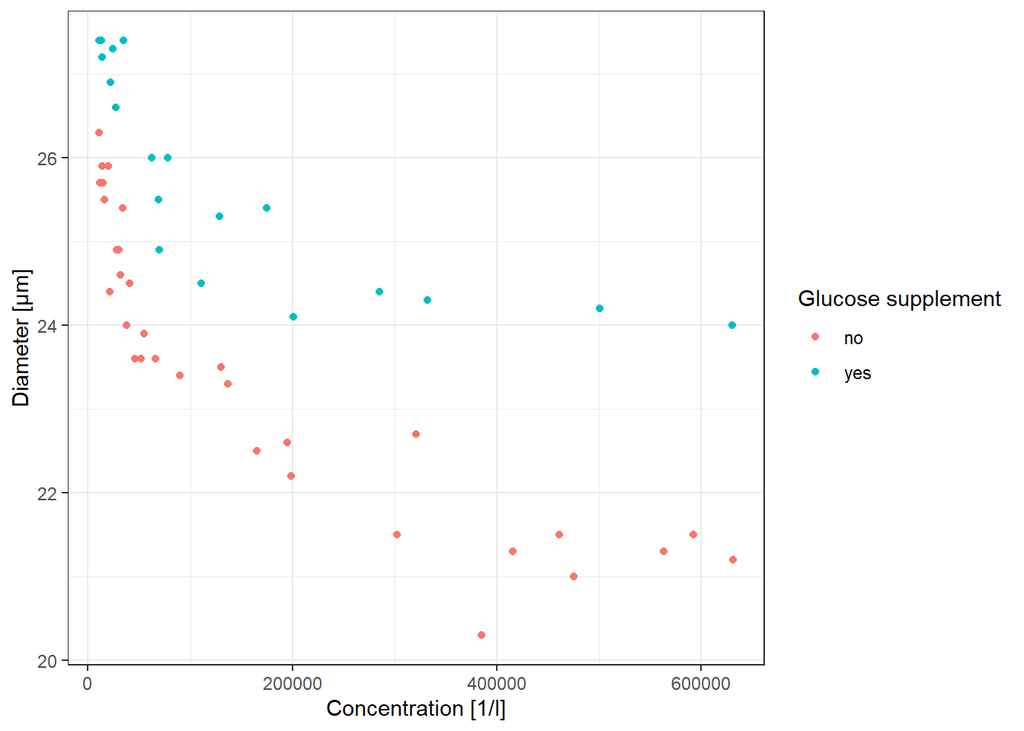

```r
tet_plot <- ggplot(tetrahymena, aes(concentration, diameter, col = glucose)) +
  geom_point() +
  labs(x = "Concentration [1/l]",
       y = "Diameter [µm]",
       col = "Glucose supplement")
tet_plot
```

There is a non-linear negative correlation between concentration and diameter. Transforming concentration with a decadal logarithm should result in a linear relationship. Cells with glucose supplements have higher average diameters.

## 3. Build a simple linear model (2 Points)

Build an appropriate linear model between diameter (response) and concentration (predictor) and visualize it graphically. Assess the assumptions and the goodness-of-fit of the model. Briefly describe your findings.

```r
# The choice between different logarithms doesn't influence goodness-of-fit,
# but log10 is easier to interpret
smodel <- lm(diameter ~ log10(concentration), tetrahymena)
summary.lm(smodel)
```

```
##
## Call:
## lm(formula = diameter ~ log10(concentration), data = tetrahymena)
##
## Residuals:
##     Min      1Q  Median      3Q     Max
## -2.1719 -0.8234 -0.4670  0.9805  2.1140
##
## Coefficients:
##                      Estimate Std. Error t value        Pr(>|t|)
## (Intercept)           37.5654     1.4271  26.322         < 2e-16 ***
## log10(concentration)  -2.7023     0.2896  -9.331 0.0000000000019 ***
## ---
## Signif. codes:  0 '***' 0.001 '**' 0.01 '*' 0.05 '.' 0.1 ' ' 1
##
## Residual standard error: 1.15 on 49 degrees of freedom
## Multiple R-squared:  0.6399, Adjusted R-squared:  0.6326
## F-statistic: 87.08 on 1 and 49 DF,  p-value: 0.000000000001901
```

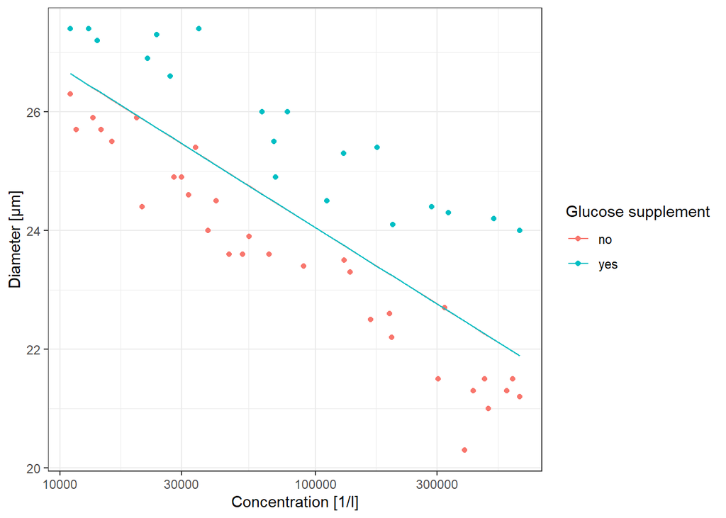

```r
tet_p2 <- augment(smodel, tetrahymena)
tet_log <- tet_plot + scale_x_log10()
tet_log + geom_line(aes(concentration, .fitted), data = tet_p2)
```

The single regression model predicts a diameter decrease by ~2.7µm per 10-fold increase in concentration with high confidence (significant at 99.9% confidence level), and with an adjusted R² of 0.6326 explains about 63% of observed variance. The graph further shows that while the regression line is a decent fit for the data overall, it doesn’t fit particular well for either with or without glucose supplement.

## 4. Multiple linear model (2 Points)

Now build a multiple linear model by adding glucose as additional predictor interacting with concentration. Compare your model to the previous one based on the AIC. Does including glucose improve the model fit?

```r
mmodel <- update(smodel, .~. * glucose)
summary.lm(mmodel)
```

```
##
## Call:
## lm(formula = diameter ~ log10(concentration) + glucose + log10(concentration):glucose,
##     data = tetrahymena)
##
## Residuals:
##     Min      1Q  Median      3Q     Max
## -1.2793 -0.1912  0.0118  0.2656  0.9552
##
## Coefficients:
##                                 Estimate Std. Error t value Pr(>|t|)
## (Intercept)                      37.5594     0.7138  52.618   <2e-16 ***
## log10(concentration)             -2.8610     0.1444 -19.820   <2e-16 ***
## glucoseyes                       -1.1224     1.2187  -0.921   0.3617
## log10(concentration):glucoseyes   0.6621     0.2479   2.670   0.0104 *
## ---
## Signif. codes:  0 '***' 0.001 '**' 0.01 '*' 0.05 '.' 0.1 ' ' 1
##
## Residual standard error: 0.4659 on 47 degrees of freedom
## Multiple R-squared:  0.9433, Adjusted R-squared:  0.9397
## F-statistic: 260.8 on 3 and 47 DF,  p-value: < 2.2e-16
```

```r
AIC(smodel)
```

```
## [1] 162.9735
```

```r
AIC(mmodel)
```

```
## [1] 72.6605
```

With an AIC of 72.661 instead of 162.974, the updated model dramatically outperforms the single regression model. The drastic increase of the adjusted R² from 0.6326 to 0.9397 provides further evidence of increased model performance.

## 5. Plot the regression lines of the multiple linear model (3 Points)

Plot the regression line for the multiple-regression model, that is one line for each class (glucose/no glucose).

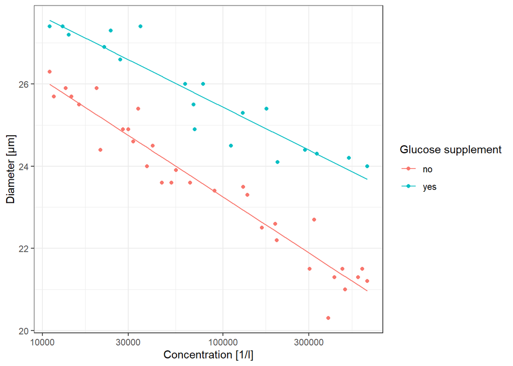

```r
tet_aug <- augment(mmodel, tetrahymena)
tet_log + geom_line(aes(concentration, .fitted, col = glucose), data = tet_aug)
```